# Initiating Phase One

Małgorzata Wachulec, Mateusz Bąkała, Wojciech Bogucki

13 - 05 - 2019

# Opis danych

Eksperyment został przeprowadzony na 30-osobowej grupie ochotników, którzy wykonywali 6 różnych aktywności: chodzenie, wchodzenie po schodach, schodzenie ze schodów, stanie, siedzienie i leżenie. Podczas eksperymentu każdy z ochotników miał w pasie telefon - Samsunga Galaxy S2 - dzięki któremu mierzone były ich prędkość oraz przyspieszenie. Parametry i statystyki tych wielkości, m.in. średnia, ochylenie standardowe, czy też kąt między wektorami znajdują się w ramce X_train oraz X_test w proporcjach 70:30. Ramki te zawierają 561 zmiennych i łącznie około 10 000 obserwacji.

Dodatkowo do naszej dyspozycji mamy też informację, o tym kto wykonywał daną czynność, dokładne wartości prędkości i przyspieszenia dla każdej obserwacji oraz informację o tym, którą z wymienionych wcześniej czynności przedstawia dana obserwacja (ramki y_train oraz y_test).

Ramka danych treningowych

| rows | 7352 |
| --- | --- |
| columns | 561 |
| discrete_columns | 0 |
| continuous_columns | 561 |
| all_missing_columns | 0 |
| total_missing_values | 0 |
| total_observations | 4124472 |
| memory_usage | 33099968 |

Wśród zmiennych występują duże korelacje:

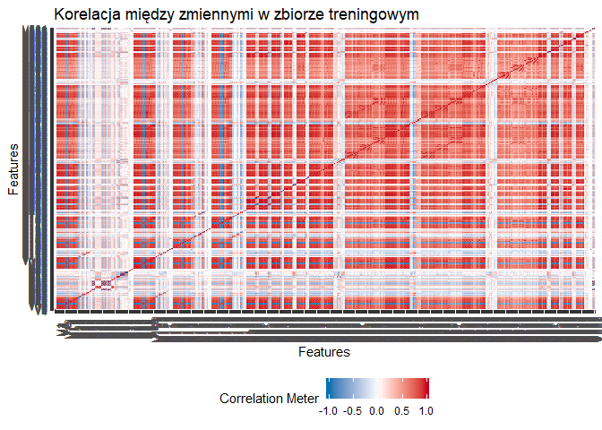

# Cel projektu

Naszym celem jest sklasteryzowanie danych tak, aby otrzymać 6 klastrów odpowiadających 6 czynnościom wykonywanych przez ochotników w eksperymencie.

# Algorytm Kmeans

Spróbujmy przewidzieć etykiety dla zbioru X_train domyślnym algorytmem K-means:

```r
podstawowy_kmeans <- kmeans(X_train,6, nstart = 40)
```

Etykiety znajdują się teraz w `podstawowy_kmeans$cluster`, lecz jeszcze nie wiemy na ile precyzyjnie są one przewidziane. Porównajmy rozmiary uzyskanych przez K-means klastrów z rozmiarami prawdziwych klastrów, wziętych z ramki y_train:

```r
# jakiej wielkości klastry uzyskaliśmy dzięki k-means
podstawowy_kmeans$size
```

```
## [1] 1551 1891  882 1389 1283  356
```

```r
# jakiej wielkości powinny być klastry?
sizes_of_clusters <- y_train[,.(.N),by=V1]
colnames(sizes_of_clusters) <- c("Etykieta","Licznosc")
sizes_of_clusters
```

| Etykieta | Licznosc |
| --- | --- |
| 5 | 1374 |
| 4 | 1286 |
| 6 | 1407 |
| 1 | 1226 |
| 3 | 986 |
| 2 | 1073 |

W następniej części wykonamy PCA i zwizualizujemy główne składowe wraz z prawdzimym rozkładem klastrów oraz z tym znalezionym przez algorytm k-means.

## PCA i klastry K-means

Jako, że wszystkie dane zawarte w X_train i X_test są znormalizowane, wystarczy wywołać na nich funkcję prcomp().

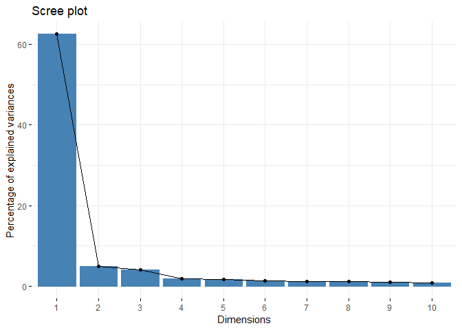

```r
pca <- prcomp(X_train)
fviz_eig(pca)
```

Jak widać na wykresie powyżej, większość wariancji jest wyjaśniona dzięki pierwszej składowej. Do wizualizacji potrzebne nam będą jedynie dwie składowe, lecz 2 i 3 składowa mają na nią podobny wpływ na wariancję, stąd zamiast rysować jedynie wykresu 2 głównych składowych, zrobimy wykresy dla 1 i 2 składowej oraz dla 1 i 3 składowej.

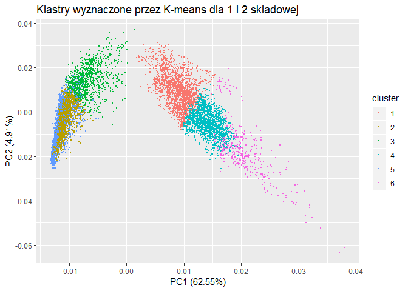

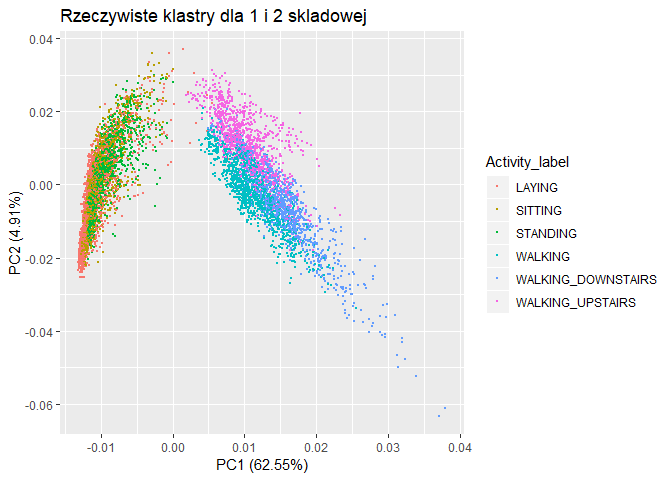

Na powyższych wykresach widać wyraźnie 2 klastry, co jest trochę problematyczne, jako że musimy znaleźć ich aż 6. W każdym z widocznych klastrów znajdują się dokładnie 3 rzeczywiste klastry. Dodatkowo rzeczywiste klastry w prawej części wykresu nie są ułożone pionowo tylko raczej tworzą wycinki owalu.

Najprawdopodobiej 2 główne zmienne mają ścisły związek z prędkością wykonywania czynności - wtedy siedzenie, stanie i leżenie można zaliczyć do aktywności statycznych, a pozostałe do aktywności dynamicznych, dlatego w każdym z widocznych klastrów znajdują się 3 rzeczywiste.

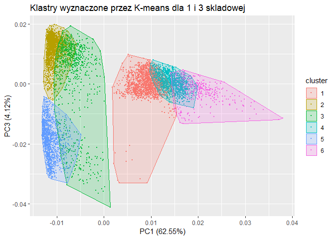

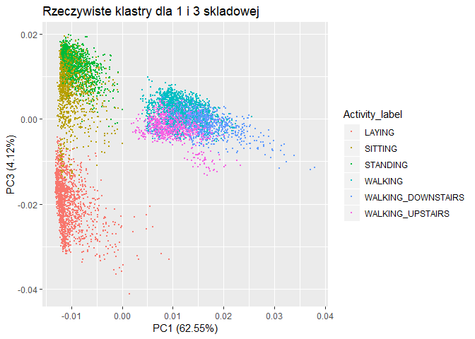

Na wykresach dotyczących 1 i 3 główych składowych widać 3 główne klastry.

Patrząc na liczności klastrów oraz wizualizację głównych zmiennych, warto byłoby wypróbować jakiś inny algorytm klasteryzacji danych.

# Klasteryzacja hierarchiczna

Spróbujemy użyć funkcji `hclust()` i porównać uzyskane w ten sposób klastry z tymi znalezionymi dzięki `kmeans()`. Żeby uzyskać etykiety, użyjemy funkcji cuttree z parametrem `k = 6`, oznaczającym liczbę klastrów.

```r
d <- dist(as.matrix(X_train), method = 'euclidean')
hierarchical_clust <- hclust(d, method = 'ward.D2')
cut <- cutree(hierarchical_clust, k = 6)
```

Oto wykres przedstawiający dwie główne składowe z klastrami znalezionymi przez algorytm hierarchiczny zaznaczonymi kolorem:

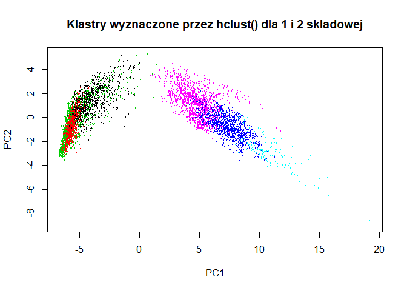

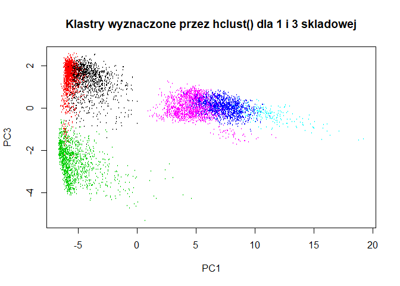

# t-SNE

PCA jest modelem liniowym, co oznacza, że nie jest w stanie wykryć nieliniowych zależności pomiędzy zmiennymi. Rozwiązaniem jest tutaj t-SNE, czyli T-distributed Stochastic Neighbor Embedding.

```r
tsne_out <- Rtsne(X_train)
```

Zamieszczony poniżej wykres przedstawia obserwacje pokolorowane według opisujących je etykiet. Możemy dostrzec charakterystyczne dla t-SNE “wyspy”, szczególnie dla spacerowania. W porównaniu do PCA niektóre kategorie rozdzielone są zauważalnie lepiej.

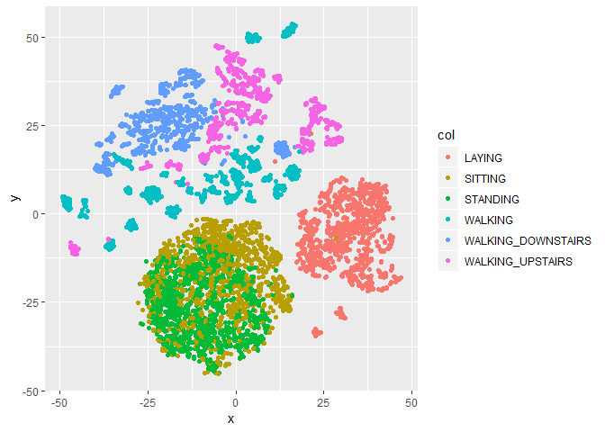